# Getting started with glmtools

Jordan S Read, Luke A Winslow

18 September, 2015

## Introduction

This package `glmtools` provides services in support using the General Lake Model (GLM) in R. GLM is a one-dimensional model that balances fluxes of energy and mass as part of dynamically simulating lake physics. The GLM model has been developed as an initiative of the Global Lake Ecological Observatory Network (GLEON) and in collaboration with the Aquatic Ecosystem Modelling Network (AEMON) that started in 2010. The model was first introduced in Leipzig at the 2nd Lake Ecosystem Modelling Symposium in 2012, and has since developed rapidly with application to numerous lakes within the GLEON network and beyond. Authors: Matthew R Hipsey, Louise C Bruce, David P Hamilton. More information about GLM can be found at http://aed.see.uwa.edu.au/research/models/GLM/.

Running GLM requires three mandatory components (in addition to several optional components). The required components include:

1. A GLM executable for the operating system being used (currently there is support for linux, windows, and mavericks/yosemite mac OSX)
2. A `glm2.nml` file, which is a configuration file for the model (see below for specifics)
3. Appropriate driver data (currently in the form of a comma-delimited time-series file)

The model generates a number of optional outputs, but will always create a `.nc` (netCDF) file which contains the simulation results.

`glmtools` has a number of utility functions that help with prepping for model runs, executing the model, and analyzing/visualizing the simulation. `glmtools` also depends on a companion package `GLM3r`, which contains the executable GLM for each supported platform and creates a unified interface for running the model across these different platforms. `GLM3r` will be automatically installed when following the instructions below.

## Installation

To install **glmtools**

Install package with dependencies:

```r
install.packages("glmtools",
    repos = c("http://owi.usgs.gov/R"),
    dependencies = TRUE)
```

## Using example data built into the package

### Find example data directory

```r
library(glmtools)
eg_folder = system.file('extdata', package = 'GLM3r')
print(eg_folder) # location of example data
```

```
## [1] "/Library/Frameworks/R.framework/Versions/3.2/Resources/library/GLM3r/extdata"
```

### List files that are included in the example data

```r
dir(eg_folder)
```

```
## [1] "glm2.nml"       "lake.csv"       "met_hourly.csv"
## [4] "output.nc"      "overflow.csv"
```

## Running GLM

### Find current version of GLM included in the package

```r
glm_version()
```

### Citing GLM

A lot of time went into the development of GLM and it is important to give the authors proper credit. To see a current citation for GLM, use the following command in R:

```r
citation('GLM3r')
```

```
##
##
##   Hipsey, M.R., Bruce, L.C., Hamilton, D.P., 2013.
##   GLM General Lake Model. Model Overview and User
##   Information. The University of Western Australia
##   Technical Manual, Perth, Australia.
##
## A BibTeX entry for LaTeX users is
##
##   @Article{,
##     author = {Matthew R. Hipsey and Louise C. Bruce and David P. Hamilton},
##     title = {GLM General Lake Model. Model Overview and User Information},
##     journal = {The University of Western Australia Technical Manual, Perth, Australia},
##     year = {2013},
##   }
##
## As GLM changes, this package will change with it, and
## the citation may change too. Find GLM version with
## 'glm_version()'.
```

### Update GLM3r if needed

If GLM3r is out of date with the current version of GLM, it is probably because this package has not been updated recently. If you would like to be able to automatically receive update recommendations via RStudio’s “Update” button, you will need to add the “http://owi.usgs.gov/R” repository to your RProfile. This can be done with:

```r
source("http://owi.usgs.gov/R/add_gran_repo.R")
update.packages()
```

Alternatively, the `repos` argument to `update.packages` and `install.packages` can be manually set to point where `GLM3r` and `glmtools` live:

```r
update.packages(repos = c("http://owi.usgs.gov/R"))
```

### Running GLM with example data

The contents of `eg_folder` (i.e., a `glm2.nml` file and a `.csv` file for the meteorological drivers) are all that is needed to run GLM from R with `GLM3r`. The `run_glm()` function simply takes a folder path to where the `glm2.nml` is as an input (the `sim_folder` argument in `run_glm`). To run example data, files can be moved to a new directory of the user’s choosing, or GLM can be run by pointing it directly at the example folder location:

```r
run_glm(eg_folder)
```

```r
dir(eg_folder)
```

```
## [1] "glm2.nml"       "lake.csv"       "met_hourly.csv"
## [4] "output.nc"      "overflow.csv"
```

### Running GLM with user data

To run GLM with user-specified data, the formats of the example data should be followed in order to properly run the simulation. Small differences in the `glm2.nml` file can result in model failures due to the inability of the model to parse certain kinds of text. When real data are used in a simulation, the user can run GLM in the same way that the example simulations were initiated. For example:

```r
run_glm('~/Documents/my_sim')
```

Below, there are a number of handy functions that support modifying the input data and model configuration.

## Interacting with nml files

```
&glm_setup
   sim_name = 'GLMSimulation'
   max_layers = 200
   min_layer_vol = 0.025
   min_layer_thick = 0.1
   max_layer_thick = 1.5
   Kw = 0.25
   coef_mix_conv = 0.33
   coef_wind_stir = 0.23
   coef_mix_shear = 0.3
   coef_mix_turb = 0.51
   coef_mix_KH = 0.3
   coef_mix_hyp = 0.5
/
```

Commented text is anything that begins with a `!`, for example:

```
!-------------------------------------------------------------------------------
! general model setup
!-------------------------------------------------------------------------------
!
! sim_name         [string]  title of simulation
! max_layers       [integer] maximum number of layers
! min_layer_vol    [real]    minimum layer volume (m3 * 1000)
! min_layer_thick  [real]    minimum layer thickness (m)
! max_layer_thick  [real]    maximum layer thickness (m)
! Kw               [real]    background light attenuation (m**-1)
! coef_mix_conv    [real]    mixing efficiency - convective overturn
! coef_wind_stir   [real]    mixing efficiency - wind stirring
! coef_mix_turb    [real]    mixing efficiency - unsteady turbulence effects
! coef_mix_shear   [real]    mixing efficiency - shear production
! coef_mix_KH      [real]    mixing efficiency - hypolimnetic Kelvin-Helmholtz turbulent billows
! coef_mix_hyp     [real]    mixing efficiency - hypolimnetic turbulence
! deep_mixing      [bool]    flag to disable deep-mixing
!
!-------------------------------------------------------------------------------
```

```r
eg_nml <- read_nml(nml_file = file.path(eg_folder,'glm2.nml'))
```

and display the `nml` contents within R:

```r
eg_nml
```

```
## &glm_setup
##    sim_name = 'GLMSimulation'
##    max_layers = 480
##    min_layer_vol = 0.025
##    min_layer_thick = 0.5
##    max_layer_thick = 1.5
##    Kw = 1.2
##    coef_mix_conv = 0.125
##    coef_wind_stir = 0.23
##    coef_mix_shear = 0.2
##    coef_mix_turb = 0.51
##    coef_mix_KH = 0.3
##    coef_mix_hyp = 0.5
## /
## &morphometry
##    lake_name = 'AwesomeLake'
##    latitude = 32
##    longitude = 35
##    bsn_len = 21000
##    bsn_wid = 13000
##    bsn_vals = 45
##    H = -252.9, -251.9, -250.9, -249.9, -248.9, -247.9, -246.9, -245.9, -244.9, -243.9, -242.9, -241.9, -240.9, -239.9, -238.9, -237.9, -236.9, -235.9, -234.9, -233.9, -232.9, -231.9, -230.9, -229.9, -228.9, -227.9, -226.9, -225.9, -224.9, -223.9, -222.9, -221.9, -220.9, -219.9, -218.9, -217.9, -2…
##    A = 0, 9250000, 15200000, 17875000, 21975000, 26625000, 31700000, 33950000, 38250000, 41100000, 46800000, 51675000, 55725000, 60200000, 64675000, 69600000, 74475000, 79850000, 85400000, 90975000, 96400000, 1.02e+08, 1.07e+08, 1.13e+08, 1.18e+08, 1.23e+08, 1.28e+08, 1.32e+08, 1.36e+08, 1.39e+08…
## /
## &time
##    timefmt = 2
##    start = '2000-04-01 00:00:00'
##    stop = '2000-08-30 00:00:00'
##    dt = 3600
##    timezone = 7
## /
## &output
##    out_dir = '.'
##    out_fn = 'output'
##    nsave = 24
##    csv_lake_fname = 'lake'
##    csv_point_nlevs = 0
##    csv_point_fname = 'WQ_'
##    csv_point_at = 17
##    csv_point_nvars = 2
```

[output cut: 65 more lines]

```
##    bsn_len_outl = 799
##    bsn_wid_outl = 399
##    outflow_fl = 'outflow.csv'
##    outflow_factor = 0.8
## /
## &snowice
##    snow_albedo_factor = 1
##    snow_rho_max = 300
##    snow_rho_min = 50
## /
## &sed_heat
##    sed_temp_mean = 9.7
##    sed_temp_amplitude = 2.7
##    sed_temp_peak_doy = 242.5
## /
```

See that `eg_nml` is an `nml` object, but behaves just like a list in R:

```r
class(eg_nml)
```

```
## [1] "nml"
```

```r
names(eg_nml)
```

```
##  [1] "glm_setup"     "morphometry"   "time"
##  [4] "output"        "init_profiles" "meteorology"
##  [7] "bird_model"    "inflow"        "outflow"
## [10] "snowice"       "sed_heat"
```

```r
eg_nml[[1]][1:4]
```

```
## $sim_name
## [1] "GLMSimulation"
##
## $max_layers
## [1] 480
##
## $min_layer_vol
## [1] 0.025
##
## $min_layer_thick
## [1] 0.5
```

### Getting information from nml

Even though the `nml` is basically just an R list, there are a number of convienence functions that help get data out of the list structure. For finding a value from a parameter, just specify the name of the parameter and use the `get_nml_value()` function:

```r
# water clarity
get_nml_value(eg_nml, 'Kw')
```

```
## [1] 1.2
```

or get values from a parameter that has a vector of values:

```r
# initial conditions for depths
get_nml_value(eg_nml, 'the_depths')
```

```
## [1]  1 10 20 30 40 46
```

### Changing nml contents

Likewise, `nml` values can be easily modified with the helper function `set_nml()`:

```r
# water clarity
eg_nml <- set_nml(eg_nml, 'Kw', 1.4)
# note how the value is now changed:
get_nml_value(eg_nml, 'Kw')
```

```
## [1] 1.4
```

`set_nml()` can use a parameter name and a corresponding value, or it can accept a list to set multiple parameters at once:

```r
eg_nml <- set_nml(eg_nml, arg_list = list('Kw' = 1.2, 'max_layers' = 480))
get_nml_value(eg_nml, 'max_layers')
```

```
## [1] 480
```

But the `nml` object is still just in memory for the R session. In order for these changes to have an impact on the simulations, the `nml` needs to be written to file

### Writing modified nml files

The `nml` object can be easily written to a user-specified location by using the `write_nml()` function:

```r
# define a location for the file to be written to. Here it will overwrite the existing `nml` file:
write_path <- file.path(eg_folder,'glm2.nml')
write_nml(eg_nml, file = write_path)
```

A new simulation can be run with the modified `nml` file:

```r
run_glm(eg_folder)
```

```
## [1] 0
```

## Visualizing GLM output

### plotting water temperatures

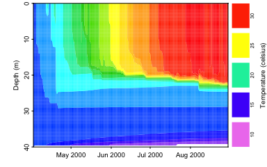

```r
nc_file <- file.path(eg_folder, 'output.nc')
plot_temp(file = nc_file)
```

### plotting multiple variables

```r
sim_vars(file = nc_file)
```

```
##         name    unit         longname
## 1       evap     m/s      evaporation
## 2  extc_coef unknown        extc_coef
## 3       hice                     hice
## 4      hsnow                    hsnow
## 5      hwice                    hwice
## 6        I_0                      I_0
## 7         NS                       NS
## 8     precip     m/s    precipitation
## 9        rad unknown  solar radiation
## 10       rho unknown          density
## 11      salt    g/kg         salinity
## 12      temp celsius      temperature
## 13     Tot_V      m3      lake volume
## 14    u_mean     m/s    mean velocity
## 15     u_orb     m/s orbital velocity
## 16         V      m3     layer volume
## 17      wind     m/s             wind
```

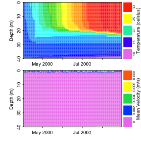

```r
plot_var(file = nc_file, var_name = c('temp','u_mean'))
```

## Validating the model against field observations

```r
sim_folder <- run_example_sim(verbose = FALSE)
nc_file <- file.path(sim_folder, 'output.nc')
field_file <- file.path(sim_folder, 'field_data.tsv')
```

create a diagnostic output within R for thermocline depth:

```r
thermo_values <- compare_to_field(nc_file, field_file,
                          metric = 'thermo.depth', as_value = TRUE)
```

Do the same for water temperatures vs field observations:

```r
temp_rmse <- compare_to_field(nc_file, field_file,
                          metric = 'water.temperature', as_value = FALSE)
print(paste(temp_rmse,'deg C RMSE'))
```

```
## [1] "1.6135543021137 deg C RMSE"
```

### Plotting comparision of water temperature vs field observations:

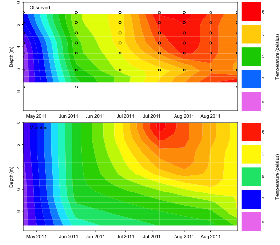

```r
sim_folder <- run_example_sim(verbose = FALSE)
nc_file <- file.path(sim_folder, 'output.nc')
nml_file <- file.path(sim_folder, 'glm2.nml')
field_file <- file.path(sim_folder, 'field_data.tsv')

plot_temp_compare(nc_file, field_file) ##makes a plot!
```

### Compare lake elevation with field measurements:

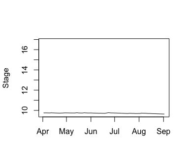

```r
field_file <- file.path(sim_folder, 'field_stage.csv')

plot_compare_stage(nc_file, field_file) ##makes a plot!
```

## glmtools function index

| Function | Title |
| --- | --- |
| `compare_to_field` | compare metric for GLM vs field observations |
| `get_evaporation` | get evaporation from GLM simulation |
| `get_hypsography` | retrieve hypsography information |
| `get_ice` | get ice depth from GLM simulation |
| `get_nml_value` | gets a nml value according to an arg_name |
| `get_surface_height` | get surface height from GLM simulation |
| `get_temp` | get water temperatures from a GLM simulation |
| `get_wind` | get wind speed from GLM simulation |
| `model_diagnostics` | run diagnostics on model results |
| `plot_temp` | plot water temperatures from a GLM simulation |
| `read_field_obs` | read in field data into a data.frame |
| `read_nml` | read in a GLM simulation `*.nml` file |
| `resample_sim` | get subset of time from a generic timeseries data.frame |
| `resample_to_field` | match GLM water temperatures with field observations |
| `set_nml` | sets values in nml object |
| `sim_metrics` | get possible metrics for comparing GLM outputs to field |
| `summarize_sim` | creates GLM simulation summary outputs |
| `validate_sim` | run diagnostics on model results vs observations |
| `write_nml` | write GLM `*.nml` for a GLM simulation |

## Running AED with GLM (Aquatic EcoDynnamics model)

coming soon